# Factors which affect Bike Rent Count and Duration.

## Investigation Overview

**In this investigation, I wanted look at what affects Bikeshare usage and Rent duration in a citywide bike share service. Bikeshare usage and Rent duration are important for a successful citywide bikeshare service. The main focus was on the age, gender, and user type of people who used the bike share service.**

## Dataset Overview

**This dataset consisted of 183412 bike rentals from the Ford GoBike bikeshare service in the San Francisco Bay area. The dataset contained 183412 entries and the data was collected from 02/01/2019 to 03/01/2019. 8460 entries out of 183412 entries were dropped due inconsistencies in the data. 700 entries were dropped while observing duration data as the those entries were extreme outliers.**

### Ratio of Subscribers vs Customers for Bike Share Service.

Most users of the bike share program were subscribers. A little over 90 percent of the users were subscribers while only 9.5 percent of the users were customers.

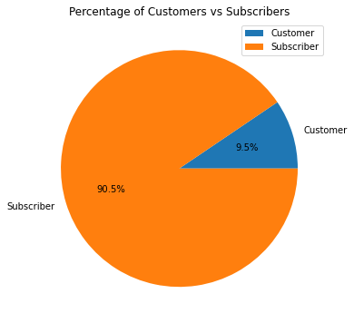

### How Gender affects Bikeshare usage.

Users of the bikeshare are overwhelmingly male. There are three times more Males than Females and Other combined.

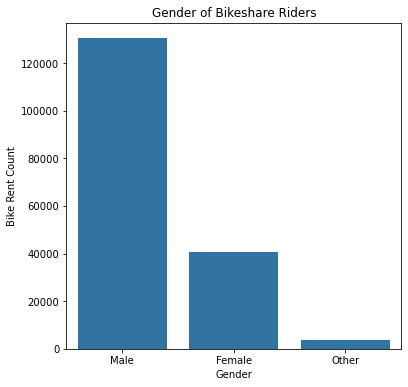

### How Age affects Bikeshare usage.

The distribution of Age vs Bike rent count is a right skewed graph. Most bikeshare users are between 20 - 40 years of age.

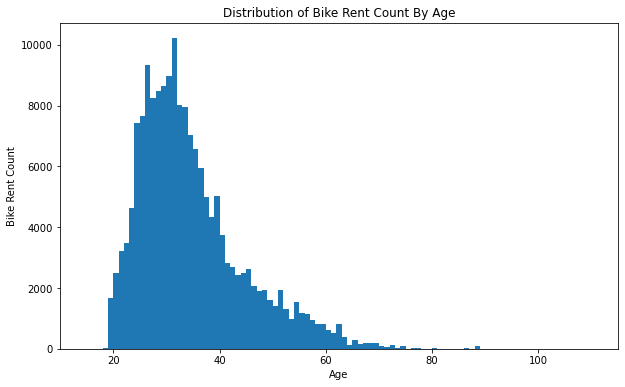

### Days of the week when most bikes were rented.

Bikes were least rented on Saturday and Sunday. Bikes were most rented on Thursday. Bikes are rented more on weekdays than weekends.

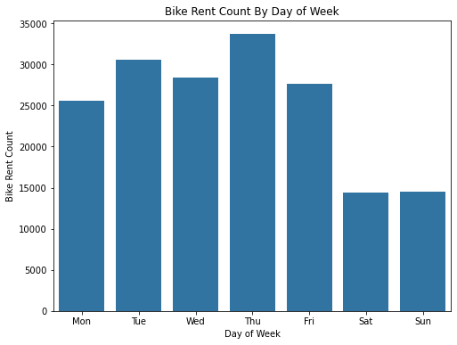

### Hours of the Day when most bikes were rented.

8:00 and 17:00 (military time) were the most popular times to rent bikes. This is probably because 8:00 was the time when people went to work, and 17:00 was when people went home. It seems that the bikes were used for commuting.

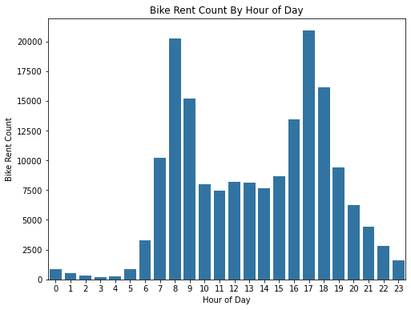

### Correlation of Age and Bikeshare Rental Duration

The pearson r value of Age and Duration is 0.01. There is no correlation between Age and bike rental duration. Also, there were extreme outliers in the dataset in terms of duration.

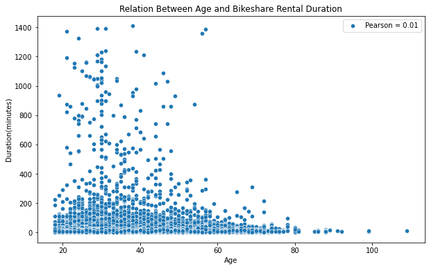

### How user type and gender affects bike rental duration.

For this analysis we got rid of 700 entries with more than 100 mins of rental time as they were extreme outliers. The bar plot below showed on average, customers have a 5 minute longer rental duration than subscribers, regardless of gender. For Subscribers Other gender have the longest duration while for Customers Females have the longest rental duration.

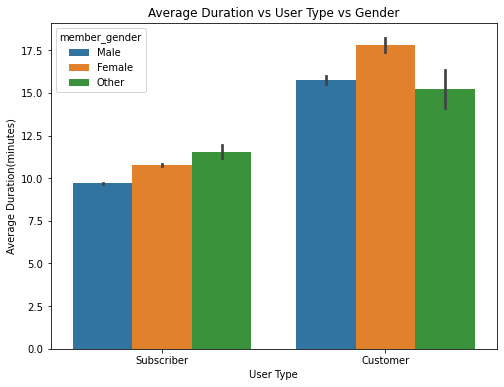